# Forecasting crime for strategic crime analysis

Matt Ashby  
UCL Department of Security and Crime Science

## What forecasting is not

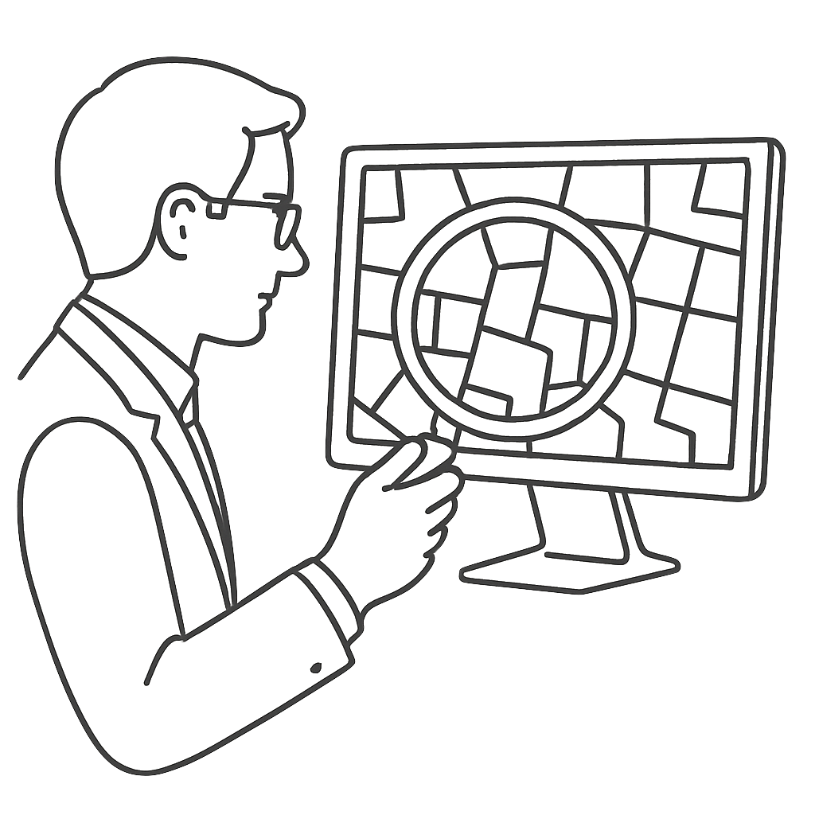

**Predictive policing**

Geography: streets

Time: hours/days into future

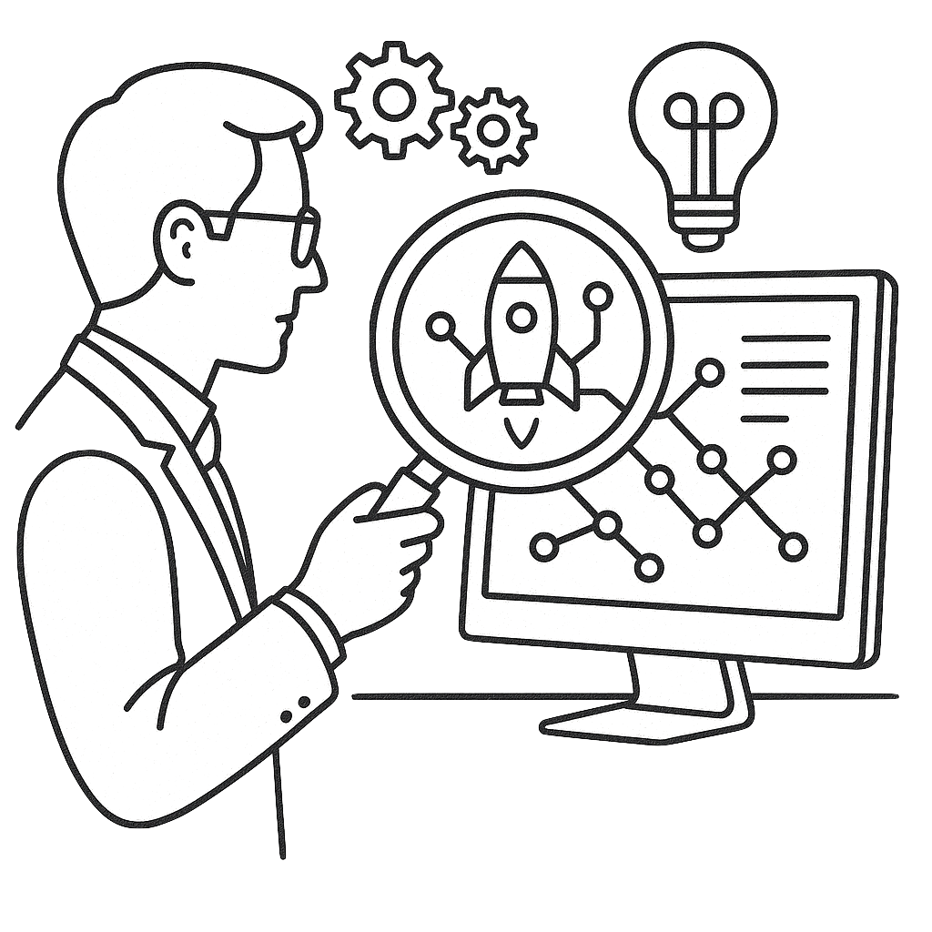

**Horizon scanning**

Geography: national/international

Time: (many) years into future

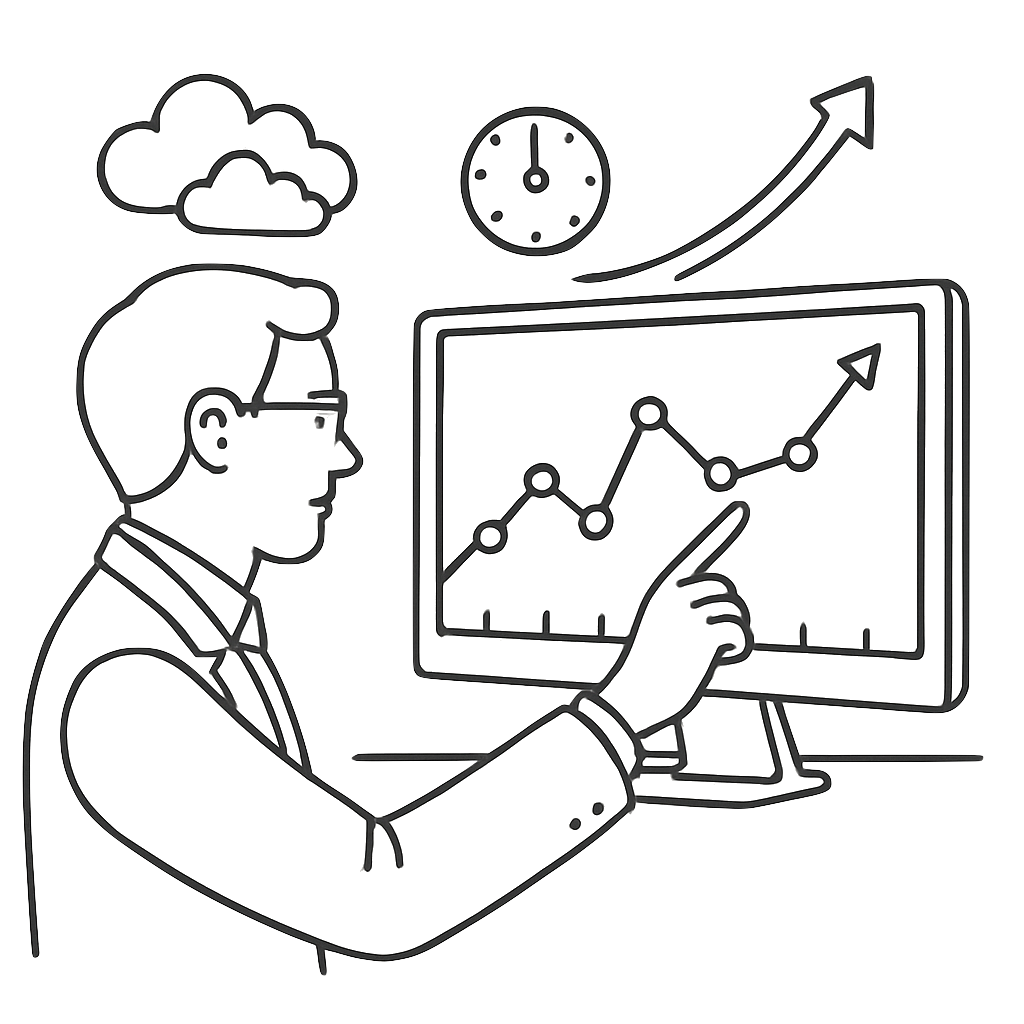

**Crime forecasting**

Geography: national/force/district

Time: weeks/months/(a few) years into future

## Forecasting uses data on the frequency of events …

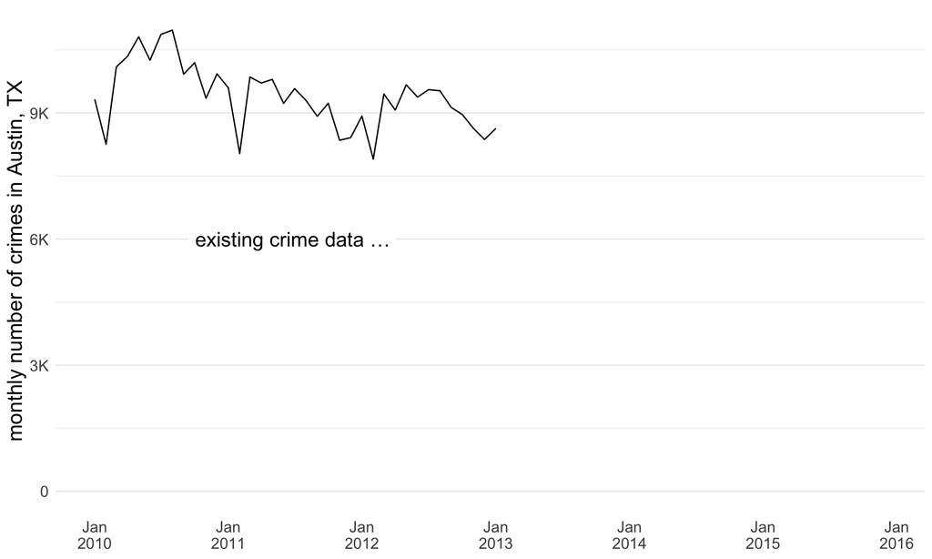

## … to estimate how many events will occur in the future

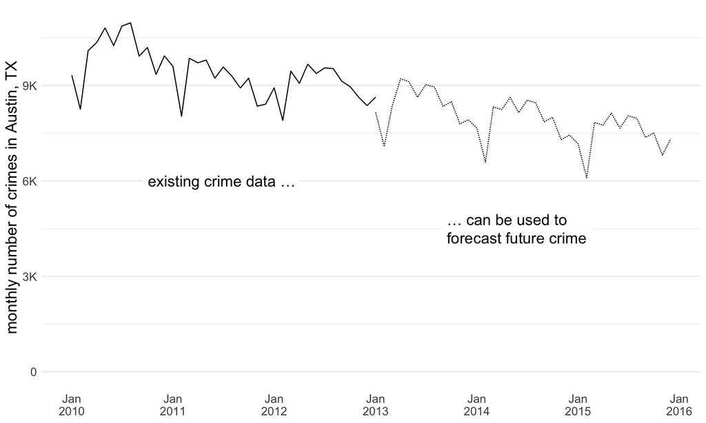

## Forecasting breaks down time series into components

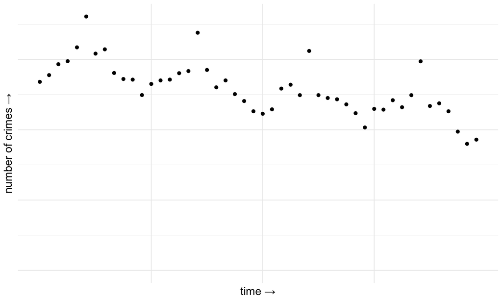

## Time series = trend +

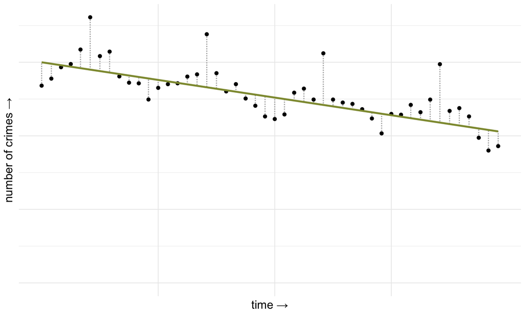

## Time series = trend + season +

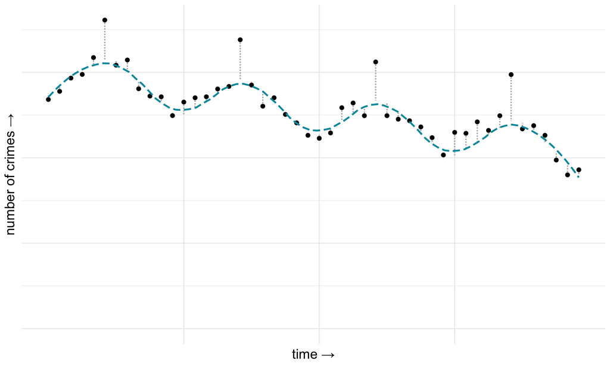

## Time series = trend + season + other

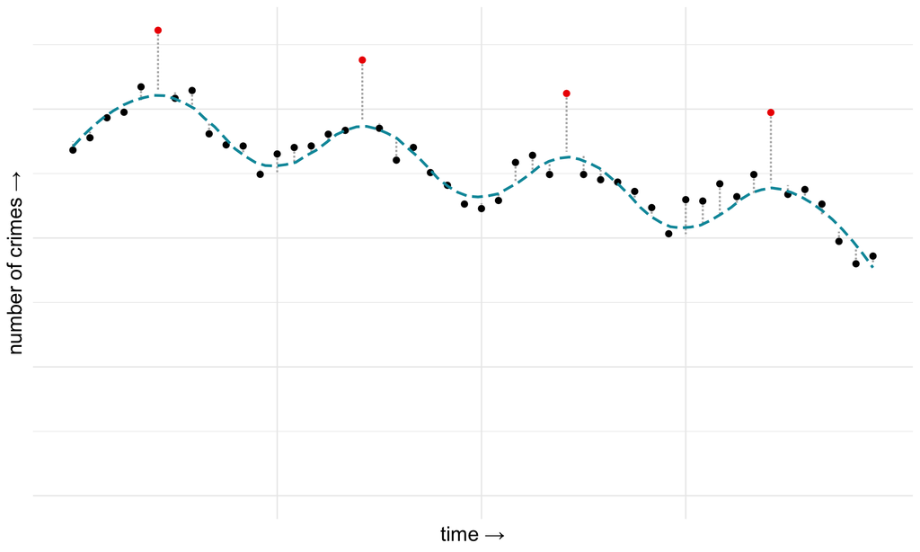

## Many repeating and one-off events can influence time series

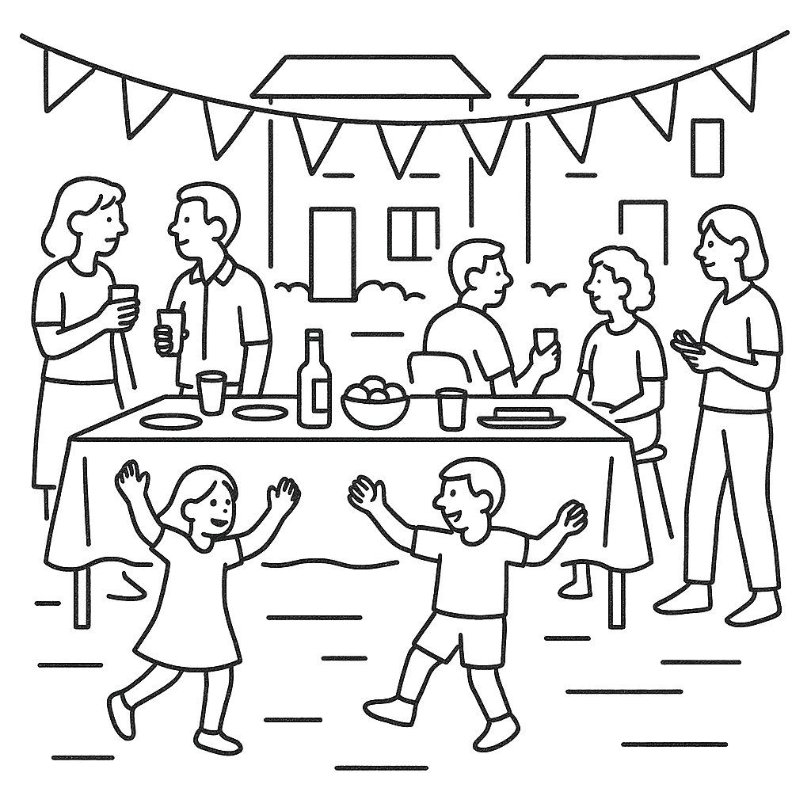

Public holidays

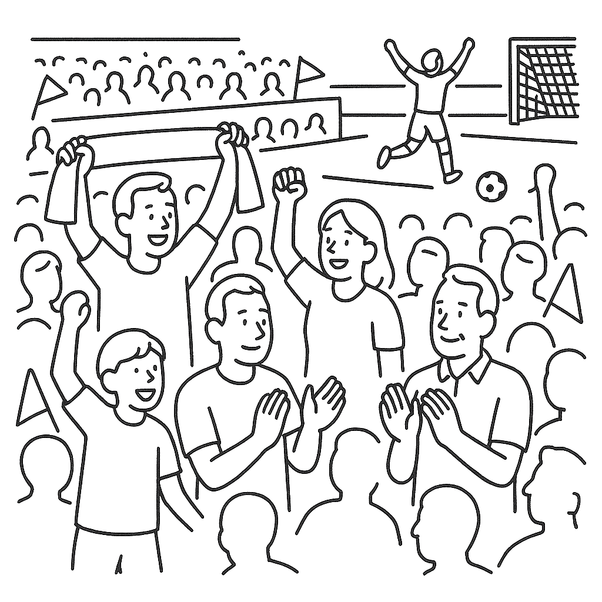

Sporting events, festivals, etc.

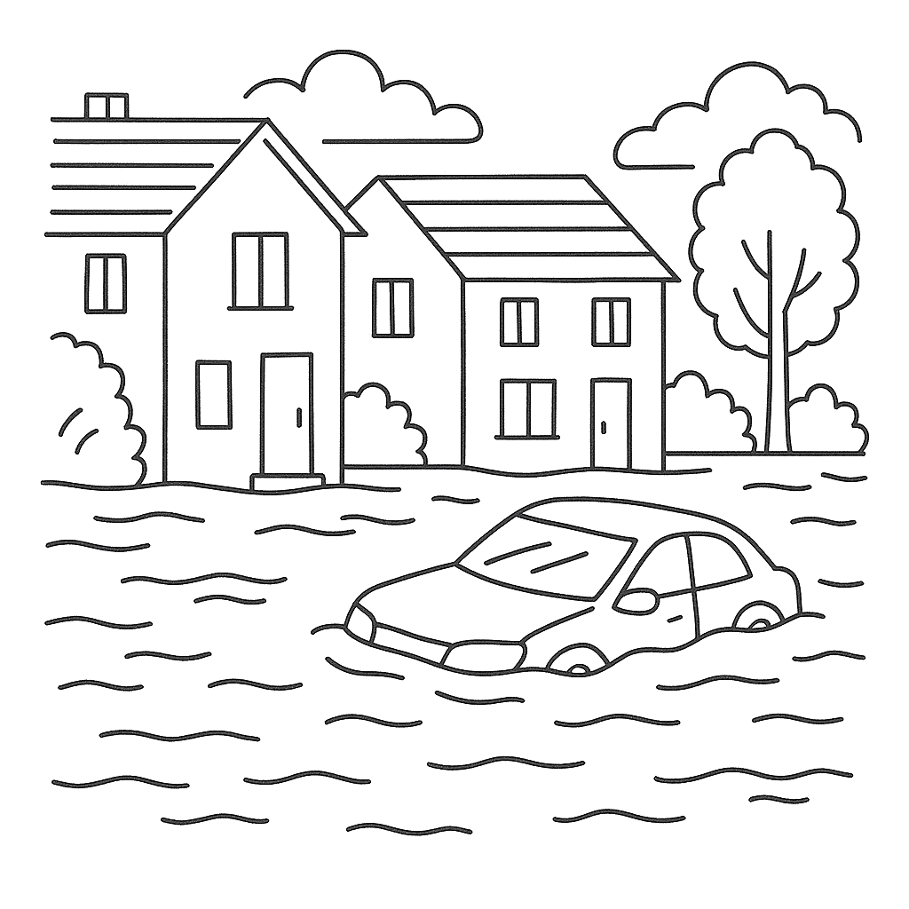

Emergencies

These are sometimes called *exogenous* variables or components

## Forecasting relies on *structural stability*

**But …**

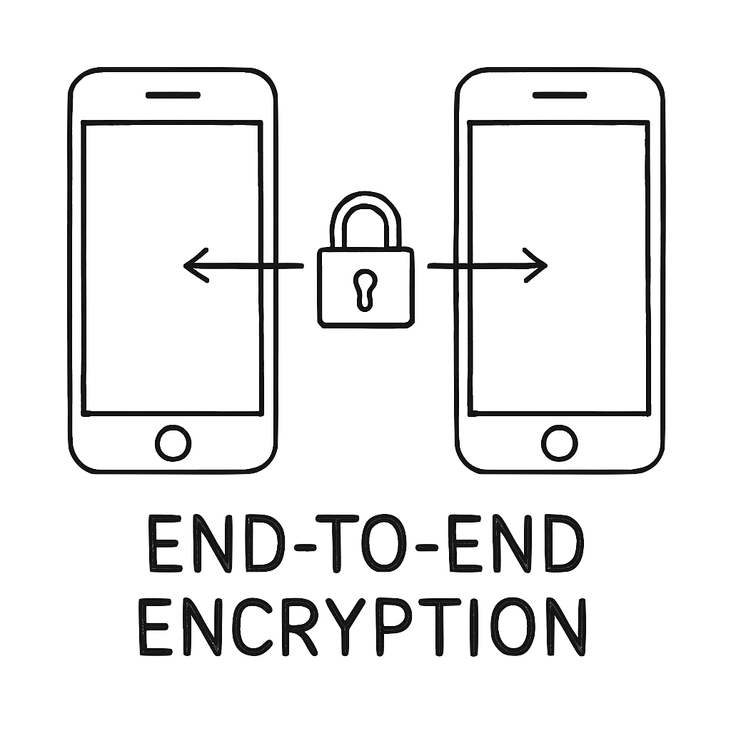

… new technologies change crime patterns

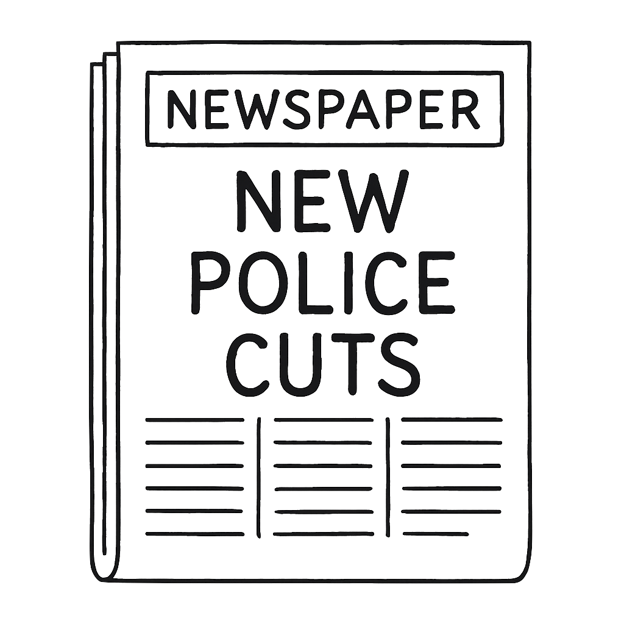

… policing itself changes

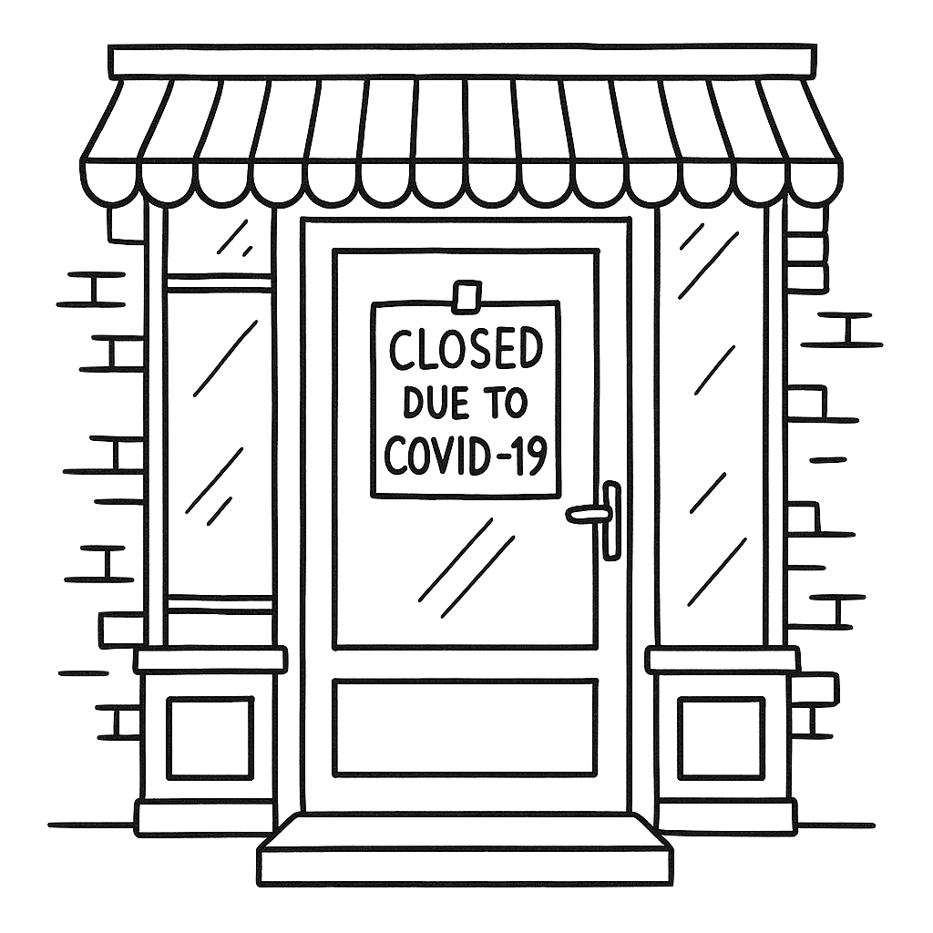

… unexpected events happen

Forecasts should be expressed as:

> If the factors underlying crime remain broadly the same, we expect …

## How forecasting can be useful to policing

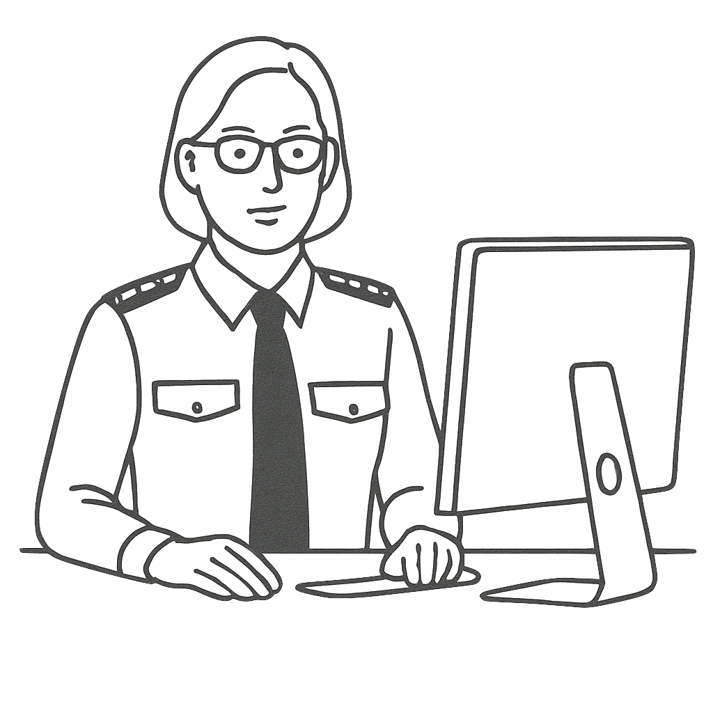

**Scenario 1**

A police commander preparing a budget request wants to know how many crimes are likely to occur in a city each month for the next three years

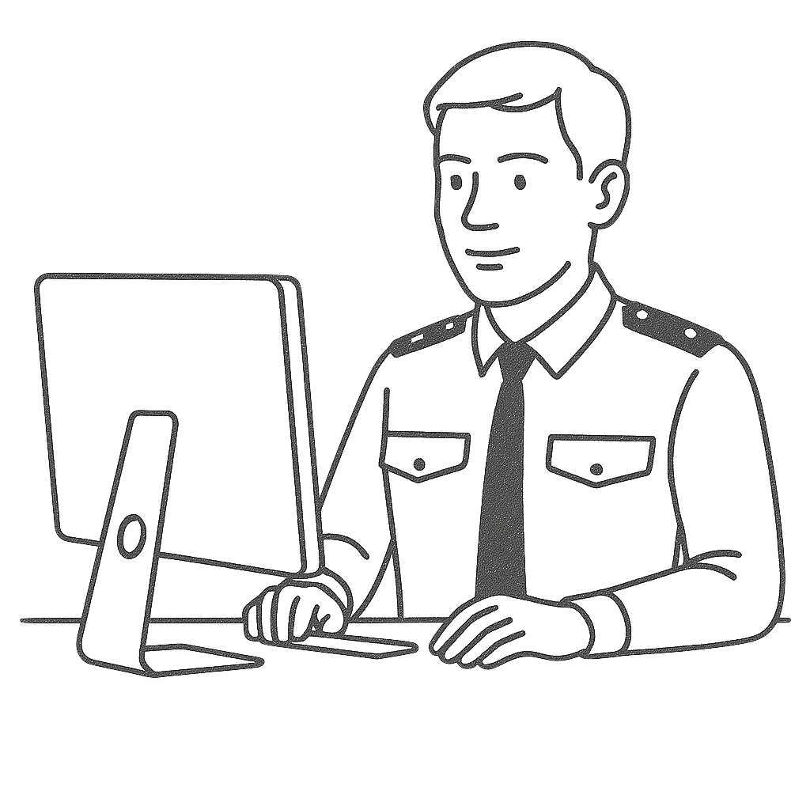

**Scenario 2**

The officer in charge of shift assignments wants to know how many crimes are likely to occur each day for the next three months.

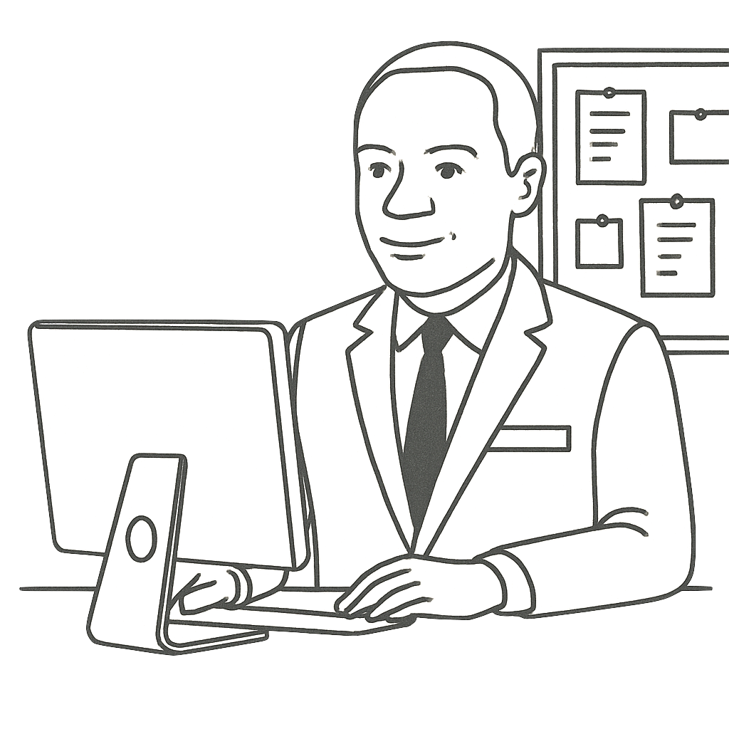

**Scenario 3**

A senior detective wants to know how many serious assaults are likely to occur in a district each month for the next year.

## But crime analysts …

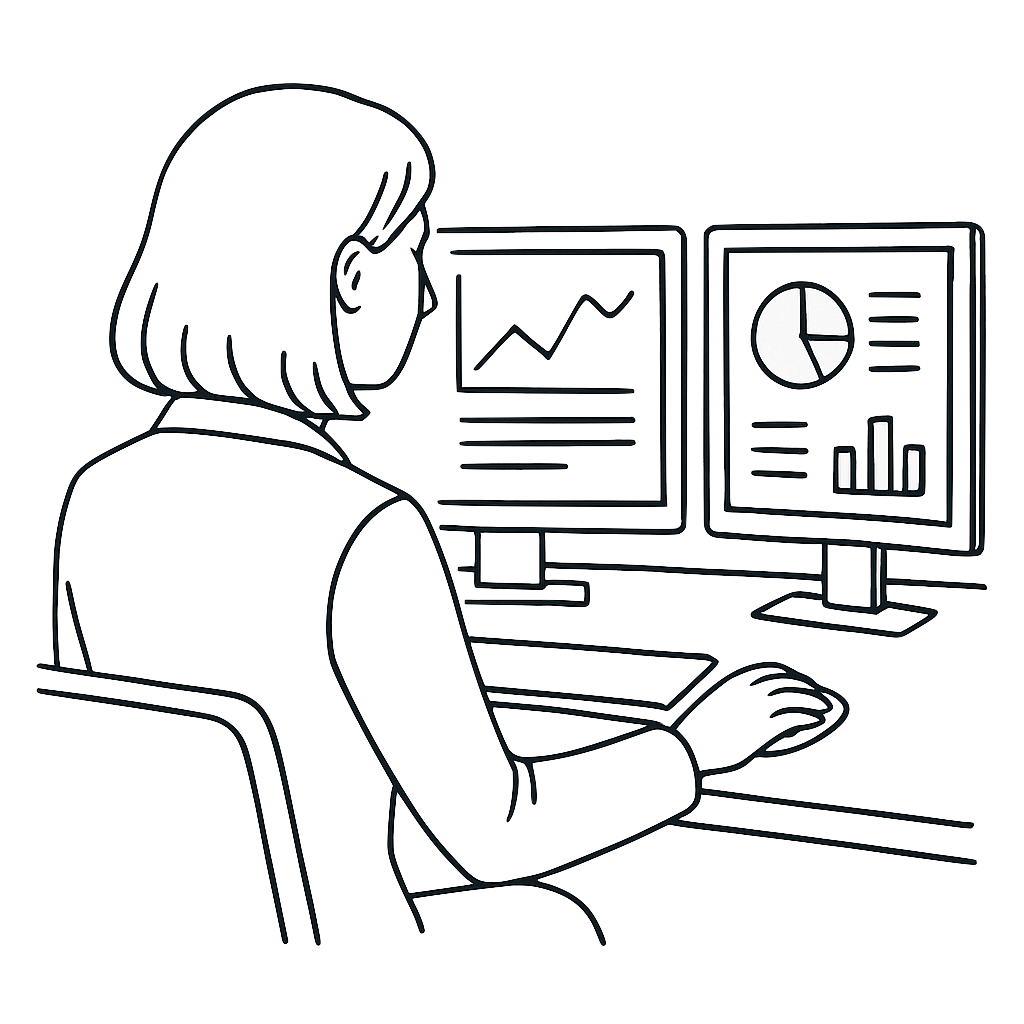

- must master lots of skills
- have limited time
- have limited software access

⇒ need forecasting to be *semi-automatic*

# Forecasting methods

## There are *many* forecasting methods

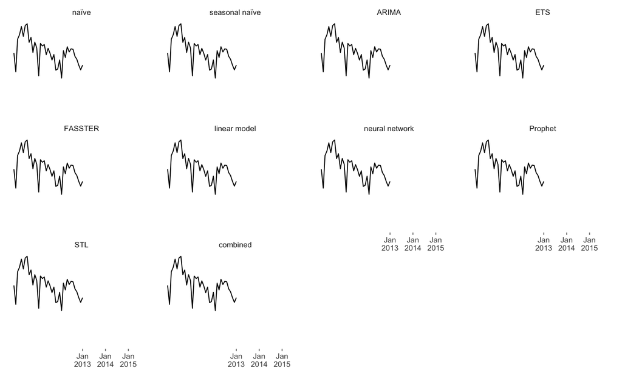

## There are *many* forecasting methods

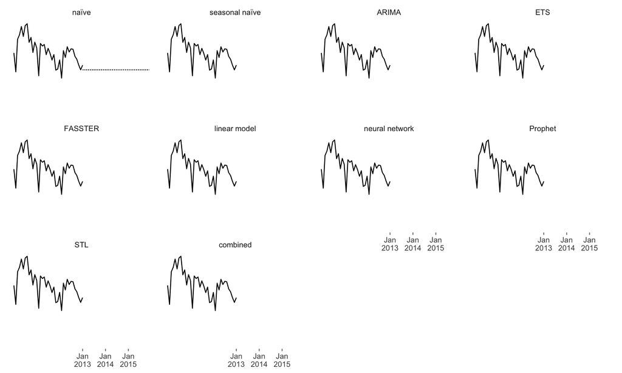

## There are *many* forecasting methods

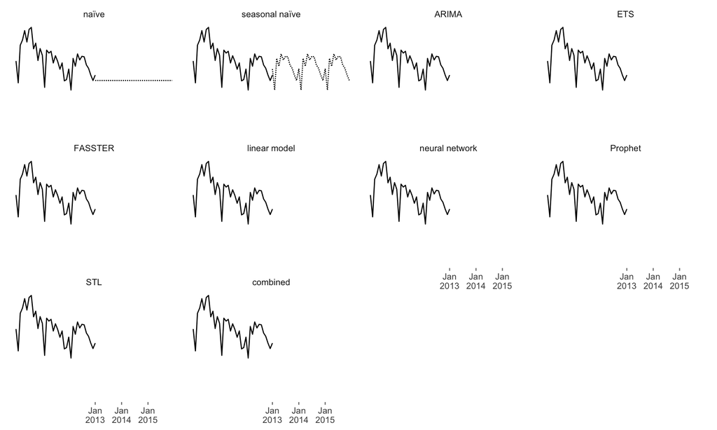

## There are *many* forecasting methods

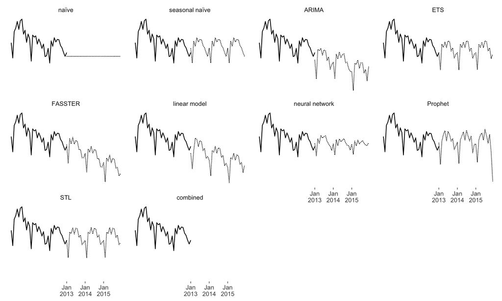

## There are *many* forecasting methods

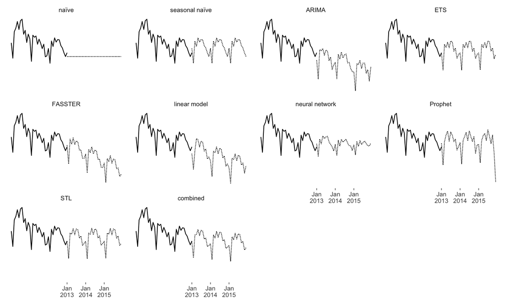

## We can assess how good forecasts are by measuring the difference between the forecast and the actual frequency of crime

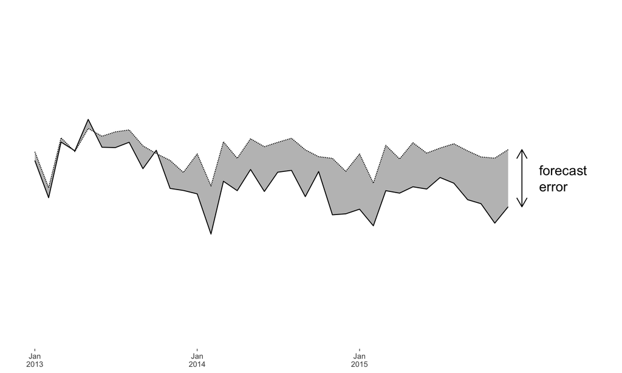

## We can compare the accuracy of different types of forecast

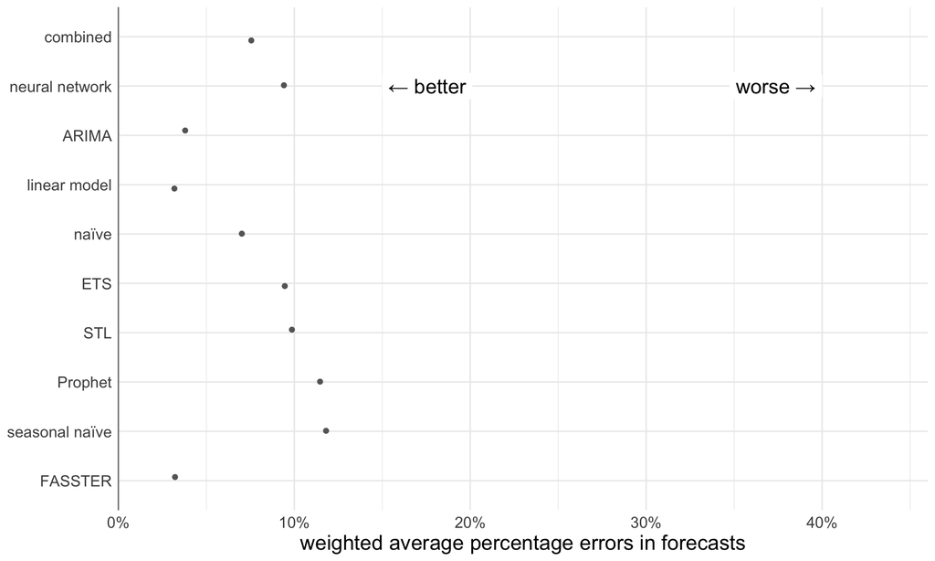

## But instead of comparing methods using only one set of forecasts …

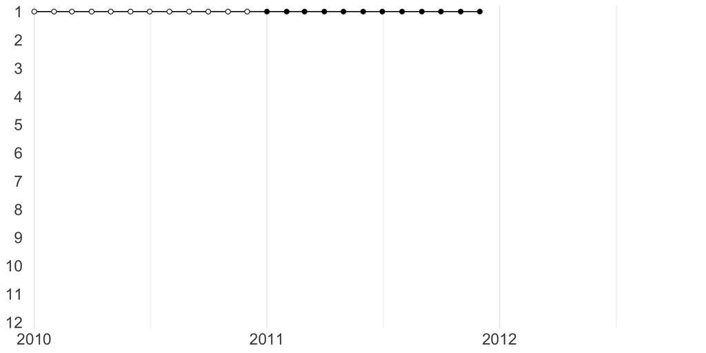

## … we can use a *rolling origin design* to compare multiple forecasts

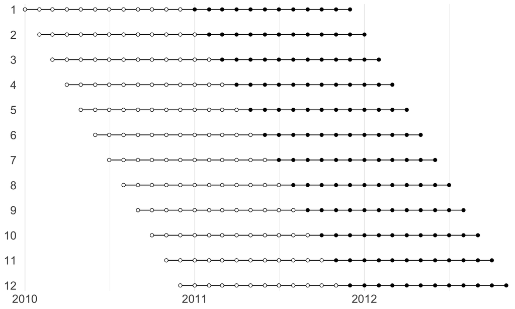

## Multiple forecasts help us better understand forecast errors

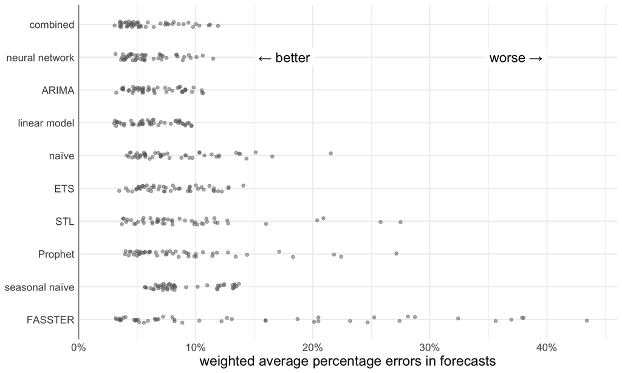

## Multiple forecasts help us better understand forecast errors

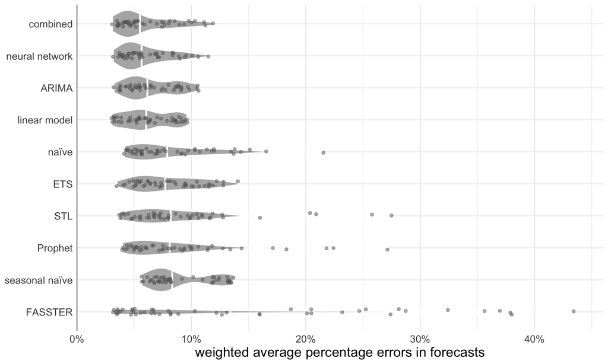

## Multiple forecasts help us better understand forecast errors

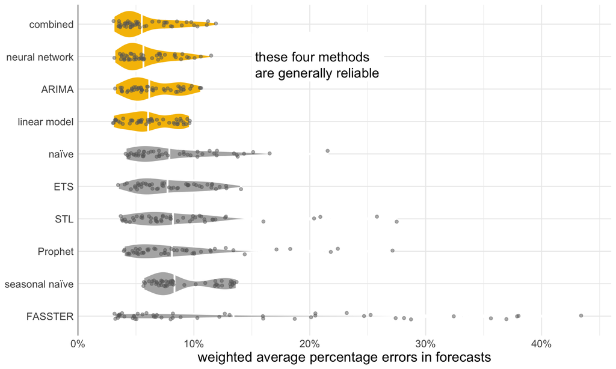

## Multiple forecasts help us better understand forecast errors

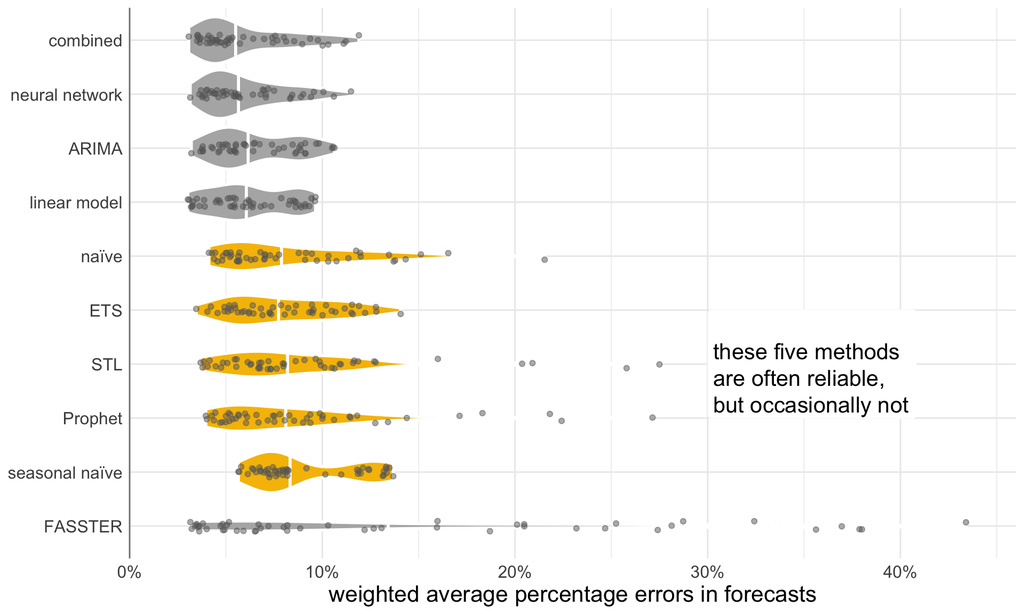